# STATS 326/786

Amir Ghobadi - Assignment 03

**General comments:**

- All the plots should be labelled appropriately (axes, legends, titles).
- Please submit both your `.Rmd`, and the generated output file `.html` or `.pdf` on Canvas before the due date/time.
- Please make sure that the `.Rmd` file compiles without any errors. The marker will not spend time fixing the bugs in your code.
- Please avoid specifying absolute paths.
- Your submission must be original, and if we recognize that you have copied answers from another student in the course, we will deduct your marks.
- You will need to use the `tidyverse` and `fpp3` libraries for this assignment.
- IMPORTANT NOTE: There are some questions that are for STATS 786 only. Students taking STATS 326, while you are welcome to attempt these questions, please do not submit answers to them.

**Due: Friday 3 May 2024 at 16:00 PM (NZ time)**

# Problem 1: Monthly Average Auckland Temperatures

In Assignments 1 and 2, you investigated monthly average temperatures in Auckland. In this problem, you will do some further analysis. The data set `auckland_temps.csv` contains the monthly average temperatures in Auckland from July 1994 until January 2024. The time series plot is given below. For this question do not Box-Cox transform the data.

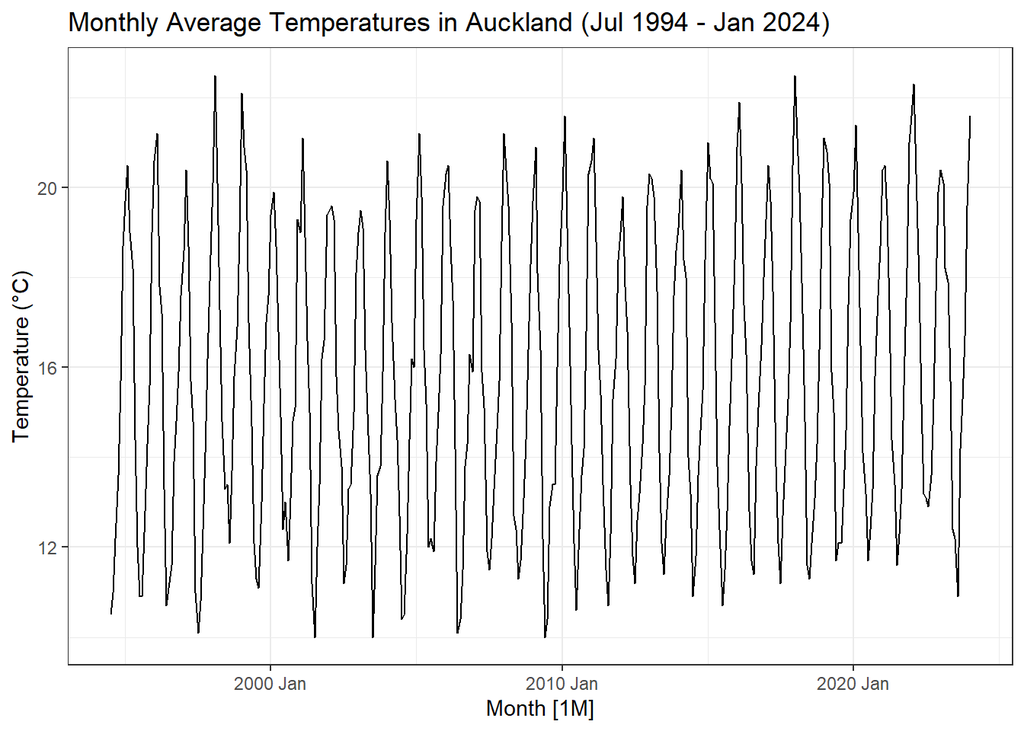

> 1. 12 Marks
> - Recall from class that you can forecast with time series decomposition by forecasting the seasonal component and seasonally-adjusted series separately. The seasonal component will automatically be forecasted using the default `SNAIVE` method, but you will need to specify which benchmark methods you are using on the seasonally-adjusted series.
> - Create a training set by filtering out the most recent 2 years from the temperature data. The training set should contain dates `1994 Jul` until `2022 Jan`.
> - Fit an STL model (with `robust = TRUE`) to the training set, and using the seasonally-adjusted series from this STL decomposition, fit the naive (`NAIVE`), the average (`MEAN`) and the random walk with drift (`RW`) benchmark forecast methods. The `decomposition_model` function will be helpful. Also fit a seasonal naive (`SNAIVE`) to the training set (without doing an STL decomposition).
> - Forecast 2 years up until `2024 Jan` so that you can compare what actually happened in the real data to what you predict would have happened with your forecast models.
> - Plot the point-forecasts with the original data with `autoplot`. Do not plot the prediction intervals (this can be achieved with the argument `level = NULL`).
> - Evaluate the point-forecasts by computing and comparing the forecast accuracy measures discussed in class.
> - Discuss which forecast method is better for monthly average Auckland temperatures, and why.

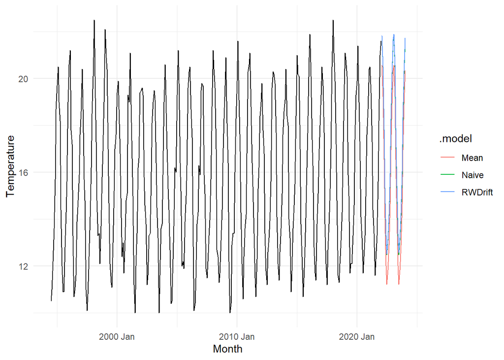

```r
training_set <- data %>%
  filter(Month < yearmonth("2022-02-01"))

stl_fit <- training_set %>%
  model(STL(Temperature ~ season(window = 7), robust = TRUE)) %>%
  components() %>% select(-.model)

stl_fit <- training_set %>%
  model(
    Naive = decomposition_model(
      STL(Temperature ~ season(window = 7), robust = TRUE),  # Applying STL decomposition
      NAIVE(season_adjust)
    ), # Random Walk with Drift on the seasonally adjusted component
    RWDrift = decomposition_model(
      STL(Temperature ~ season(window = 7), robust = TRUE),
      RW(season_adjust ~ drift())
    ), # Mean forecasting on the seasonally adjusted component
    Mean = decomposition_model(
      STL(Temperature ~ season(window = 7), robust = TRUE),
      MEAN(season_adjust)
    )
  )

stl_fit %>%
  forecast(h = "2 years") %>%
  autoplot(training_set, level = NULL) +
  theme_minimal()
```

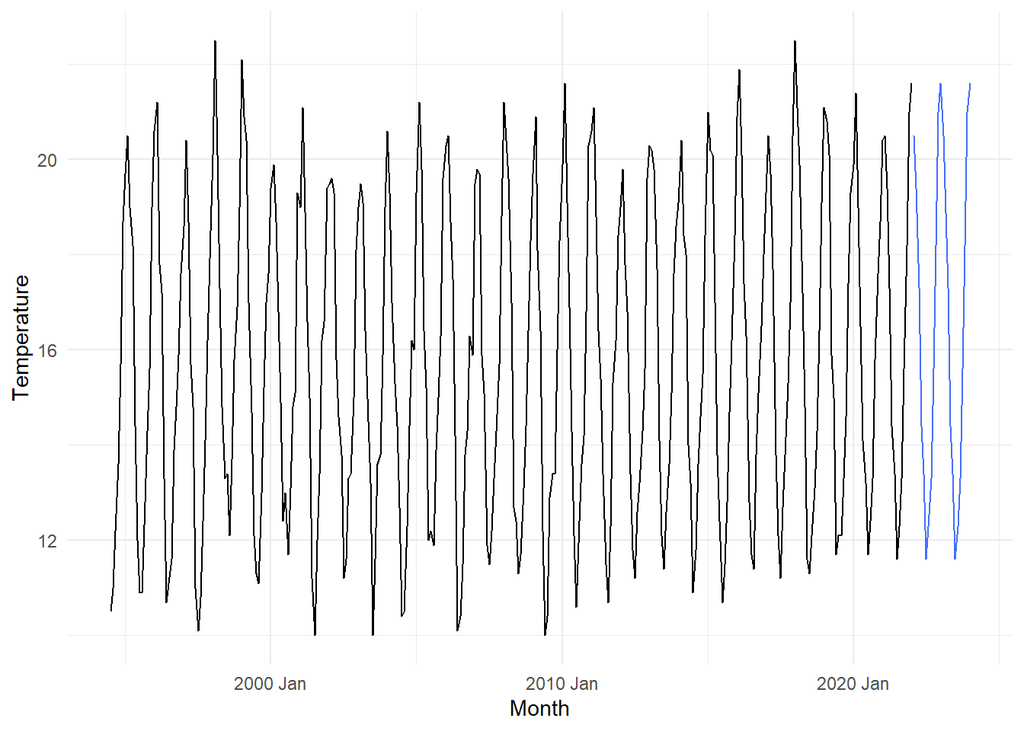

```r
seasonal_naive <- training_set %>%
       model(SNAIVE = SNAIVE(Temperature))

seasonal_naive %>%
  forecast(h = "2 years") %>%
  autoplot(training_set, level = NULL) +
  theme_minimal()
```

```r
accuracy(stl_fit)
```

```
## # A tibble: 3 × 10
##   .model  .type          ME  RMSE   MAE    MPE  MAPE  MASE RMSSE   ACF1
##   <chr>   <chr>       <dbl> <dbl> <dbl>  <dbl> <dbl> <dbl> <dbl>  <dbl>
## 1 Naive   Training  0.00414 0.931 0.681 -0.121  4.47 0.757 0.804 -0.394
## 2 RWDrift Training -0.00142 0.931 0.681 -0.158  4.47 0.757 0.804 -0.394
## 3 Mean    Training  0.0118  0.787 0.562 -0.160  3.71 0.625 0.680  0.299
```

```r
accuracy(seasonal_naive)
```

```
## # A tibble: 1 × 10
##   .model .type        ME  RMSE   MAE     MPE  MAPE  MASE RMSSE  ACF1
##   <chr>  <chr>     <dbl> <dbl> <dbl>   <dbl> <dbl> <dbl> <dbl> <dbl>
## 1 SNAIVE Training 0.0411  1.16   0.9 -0.0216  5.87     1     1 0.326
```

> Total marks for **Problem 1**: 12 Marks